# Session 2: R Operators, Variables, & Data Types

Mobina Pourmoshir

1/26/2024

# Using R as a Calculator

### Arithmetic Operators

R operators play a crucial role in mathematical computing, facilitating various tasks, including pre-processing steps like data transformation. For example, one might perform calculations such as BMI = weight (lb) / [height (in)]^2 * 703.

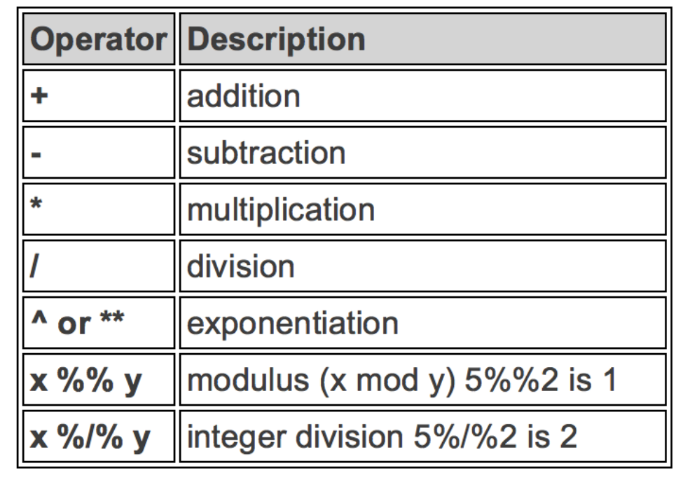

# Arithmetic Operators

### Examples

```r
7 + 4  # addition
```

```
## [1] 11
```

```r
8 * 9 # multiplication
```

```
## [1] 72
```

```r
17 / 3 # division
```

```
## [1] 5.666667
```

```r
4 ^ 3 # power
```

```
## [1] 64
```

```r
exp(4) # exponential function
```

```
## [1] 54.59815
```

```r
log(12) # natural log function
```

```
## [1] 2.484907
```

```r
3.1415 * log(3)/(7 - atan(8))
```

```
## [1] 0.6214557
```

# Using R as a Calculator

### Logical and Comparative Operators

We use logical operators when we have Conditional Statements like if, else if, and else to control the flow of the program based on certain conditions.

As an example, sometimes we want to filter a part of our data using conditional statements.

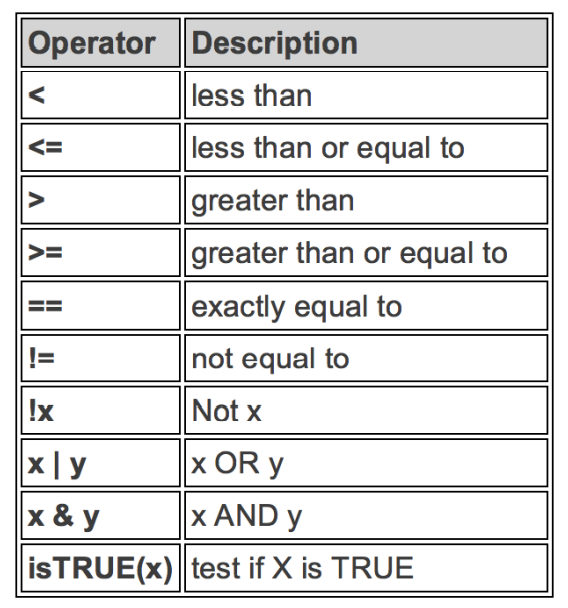

# Logical and Comparative Operators

### Examples

```r
5 <= 5
```

```
## [1] TRUE
```

```r
5 <=4
```

```
## [1] FALSE
```

```r
# 5 and 5.00 and 5.000 are of the same value
5 == 5.00
```

```
## [1] TRUE
```

```r
# 5 and 5L are of the same value too
# 5 is of type double; 5L is of type integer
5 == 5L
```

```
## [1] TRUE
```

```r
# Is 5 is NOT equal to 5? FALSE
5 != 5
```

```
## [1] FALSE
```

```r
# Is TRUE equal to FALSE?
TRUE == FALSE
```

```
## [1] FALSE
```

```r
# Is TRUE not equal to FALSE?
TRUE != FALSE
```

```
## [1] TRUE
```

```r
# Is not TRUE equal to FALSE?
!TRUE == FALSE
```

```
## [1] TRUE
```

```r
# TRUE if either one is TRUE or both are TRUE
TRUE | FALSE
```

```
## [1] TRUE
```

```r
# TRUE if both are TRUE
TRUE & FALSE
```

```
## [1] FALSE
```

# Built-in Functions

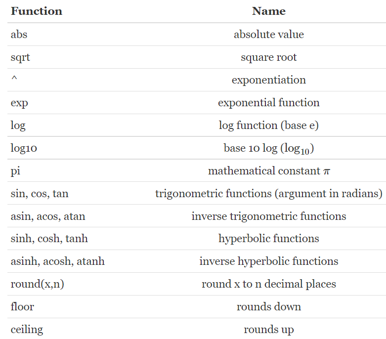

# Built-in Functions

### Examples

```r
abs(3-6) # absolute value
```

```
## [1] 3
```

```r
sqrt(9)
```

```
## [1] 3
```

```r
(1 + 0.03)^5 # association
```

```
## [1] 1.159274
```

```r
exp(4) # exponential function
```

```
## [1] 54.59815
```

```r
log(12) # natural log function
```

```
## [1] 2.484907
```

```r
log10(100)
```

```
## [1] 2
```

```r
3.1415 * log(3)/(7 - atan(8))
```

```
## [1] 0.6214557
```

```r
round(pi,2)
```

```
## [1] 3.14
```

```r
floor(14.7)
```

```
## [1] 14
```

```r
ceiling(14.7)
```

```
## [1] 15
```

# Commenting

You’ve seen comments a lot!  
How do you add a comment in R?

- Use **#** to add a comment so that the text after **#** is not read as an R command.
- Writing (good) comments is highly recommended: help readers and more importantly yourself understand what the code is doing.
- Comments should explain the why, not the what.

# Objects and Funtions in R

- Everything that exists is an object.
- Everything that happens is a function call.
- John Chambers, the creator of the S programming language.
- We have made lots of things happened!
- Even arithmetic and logical operators are functions!

# Assignment Operator

Results of calculations can be stored in objects using the assignment operators:

- an arrow `<-` formed by a smaller than character and a hyphen without a space; the equal character `=`.
- Many R users have suggested using `<-`, not `=`, for assignment.

```r
x <- sin(0)
y <- 3.1415 * cos(pi)
z <- x + y
x
```

```
## [1] 0
```

```r
y
```

```
## [1] -3.1415
```

```r
z
```

```
## [1] -3.1415
```

### Creating Variables

- A variable stores a value that can be changed according to our need.
- Use `<-` operator to assign a value to the variable. (Highly recommended)

```r
x <- 7 # we assign the value 7 to the variable named x which is an object
x # type the variable name to see the value stored in the object x
```

```
## [1] 7
```

- Can also use `=` symbol to do assignment.

```r
x <- x + 6 # We can reassign any value to the variable we created

x == 7 # We can perform any operations on variables
```

```
## [1] FALSE
```

```r
log(x) # Variables can also be used in any built-in functions
```

```
## [1] 2.564949
```

# Objects in R

Vectors and matrices are two of several types of objects in R.  
Other types of objects are lists, factors, and data frames.

- To create a vector, use `c()`, short for concatenate or combine.
- A vector can be defined according to the data type it contains. There are
- numeric vectors;
- logical (or Boolean) vectors;
- character (or string) vectors.

### Vectors

```r
a <- c(3, 3.1, 3.14, pi, -pi, cos(pi))
b <- c("I", "Love", "Pie") # character vector
c <- c(TRUE,TRUE,TRUE,FALSE,TRUE,FALSE) #logical vector
a
```

```
## [1]  3.000000  3.100000  3.140000  3.141593 -3.141593 -1.000000
```

```r
b
```

```
## [1] "I"    "Love" "Pie"
```

```r
c
```

```
## [1]  TRUE  TRUE  TRUE FALSE  TRUE FALSE
```

- Vectors of sequential numerical values can be created using sequences using the operator `:` or using the `seq()` function.

```r
vf <- 1:15 # generate integer sequence from 1 to 15
vf
```

```
##  [1]  1  2  3  4  5  6  7  8  9 10 11 12 13 14 15
```

```r
vb <- 15:1  # generate integer sequence from 15 to 1
vb
```

```
##  [1] 15 14 13 12 11 10  9  8  7  6  5  4  3  2  1
```

```r
seq.by <- seq(from = 1, to = 15, by = 2) # generate a sequence from 1 to 15 incremented by 2
seq.by
```

```
## [1]  1  3  5  7  9 11 13 15
```

```r
seq.len <- seq(from = 1, to = 15, length.out = 8) # generate a sequence from 1 to 15 of length 8
seq.len
```

```
## [1]  1  3  5  7  9 11 13 15
```

### Accessing vectors

- Refer to elements of a vector using its position (or “index”),indicated using square brackets.
- You can access multiple elements of a vector by specifying a vector of element indices inside the square brackets.

```r
b[2] # second entry of vector char
```

```
## [1] "Love"
```

```r
a[c(2,4)] # 2nd and 4th elements of vector
```

```
## [1] 3.100000 3.141593
```

```r
b[-3] # displays the sub-vector excluding the 3 entry
```

```
## [1] "I"    "Love"
```

- If a vector mixes different data types, R will store it as a character vector.

```r
mixed <- c("I", "Love", 3)
mixed
```

```
## [1] "I"    "Love" "3"
```

Logical vectors are often defined as the result of control actions on numerical or character vectors.

```r
a
```

```
## [1]  3.000000  3.100000  3.140000  3.141593 -3.141593 -1.000000
```

```r
logic1 <- a > 2
logic1
```

```
## [1]  TRUE  TRUE  TRUE  TRUE FALSE FALSE
```

# Types of Variables

- Use R command `typeof()` to check which type a variable belongs to.
- Common types include character, double, integer and logical.
- Check if a variable is of a specific type: `is.character()`, `is.double()`, `is.integer()`, `is.logical()`.

### Example

```r
typeof(8)
```

```
## [1] "double"
```

```r
typeof(5L)
```

```
## [1] "integer"
```

```r
typeof("I love this 4730 class!")
```

```
## [1] "character"
```

```r
typeof(1 > 3)
```

```
## [1] "logical"
```

```r
is.double(5L)
```

```
## [1] FALSE
```

# Variable Types in R

- Type character and logical correspond to categorical variables.
- Type double and integer correspond to numerical variables.
- Type double is for continuous variables and integer for discrete variables.
- Both double and integer types are of numeric mode. This can be verified using the function `mode()`; the storage mode of an object.

```r
mode(5)
```

```
## [1] "numeric"
```

```r
mode(5L)
```

```
## [1] "numeric"
```

```r
is.numeric(5)
```

```
## [1] TRUE
```

```r
is.numeric(5L)
```

```
## [1] TRUE
```

- Type logical is a special type of categorical variables that has only two categories.
- We usually call it a binary variable.

# More on Objects

### Data Types

R has a wide variety of data types including scalars, vectors (numerical, character, logical), matrices, data frames, and lists.

### Matrices

All columns in a matrix must have the **same mode** (numeric, character, etc.) and the **same length**.  
A matrix is defined using the `matrix()` function. The general format is

`mymatrix <- matrix(vector, nrow=r, ncol=c, byrow=FALSE, dimnames=list(char_vector_rownames, char_vector_colnames))`

- **byrow=TRUE** indicates that the matrix should be filled by rows.
- **byrow=FALSE** indicates that the matrix should be filled by columns (the default).
- **dimnames** provides optional labels for the columns and rows.

```r
# generates 5 x 4 numeric matrix
y<-matrix(1:20, nrow=5,ncol=4)
y
```

```
##      [,1] [,2] [,3] [,4]
## [1,]    1    6   11   16
## [2,]    2    7   12   17
## [3,]    3    8   13   18
## [4,]    4    9   14   19
## [5,]    5   10   15   20
```

```r
# another example
cells <- c(1,26,24,68)
rnames <- c("R1", "R2")
cnames <- c("C1", "C2")
mymatrix <- matrix(cells, nrow=2, ncol=2, byrow=TRUE,
  dimnames=list(rnames, cnames))
mymatrix
```

```
##    C1 C2
## R1  1 26
## R2 24 68
```

Identify rows, columns or elements using subscripts.

```r
mymatrix[,2] # 2nd column of matrix
```

```
## R1 R2
## 26 68
```

```r
mymatrix[1,] # 1st row of matrix
```

```
## C1 C2
##  1 26
```

```r
y[2,1:3] # row 2 of columns 1,2,3
```

```
## [1]  2  7 12
```

### Arrays

Arrays are similar to matrices but can have more than two dimensions. See help(array) for details.

# Data Types

### Data Frames

A data frame is more general than a matrix, in that different columns can have different modes (numeric, character, factor, etc.). This is similar to SAS and SPSS datasets.

```r
d <- c(1,2,3,4)
e <- c("red", "white", "red", NA)
f <- c(TRUE,TRUE,TRUE,FALSE)
mydata <- data.frame(d,e,f)
names(mydata) <- c("ID","Color","Passed") # variable names
mydata
```

```
##   ID Color Passed
## 1  1   red   TRUE
## 2  2 white   TRUE
## 3  3   red   TRUE
## 4  4  <NA>  FALSE
```

There are a variety of ways to identify the elements of a data frame .

```r
mydata[2:3] # columns 2,and 3 of data frame
```

```
##   Color Passed
## 1   red   TRUE
## 2 white   TRUE
## 3   red   TRUE
## 4  <NA>  FALSE
```

```r
mydata[c("ID","Passed")] # columns ID and Passed from data frame
```

```
##   ID Passed
## 1  1   TRUE
## 2  2   TRUE
## 3  3   TRUE
## 4  4  FALSE
```

```r
mydata$Color # variable Color in the data frame
```

```
## [1] "red"   "white" "red"   NA
```

# Data Types

### Lists

- An ordered collection of objects (components).
- A list allows you to gather a variety of (possibly unrelated) objects under one name.
- Create a list using the `list()` function.

```r
# example of a list with 4 components -
# a string, a numeric vector, a matrix, and a scaler
w <- list(name="Fred", mynumbers=a, mymatrix=y, age=5.3)
w
```

```
## $name
## [1] "Fred"
##
## $mynumbers
## [1]  3.000000  3.100000  3.140000  3.141593 -3.141593 -1.000000
##
## $mymatrix
##      [,1] [,2] [,3] [,4]
## [1,]    1    6   11   16
## [2,]    2    7   12   17
## [3,]    3    8   13   18
## [4,]    4    9   14   19
## [5,]    5   10   15   20
##
## $age
## [1] 5.3
```

```r
v <- list(numeric=a , charact=b, loggical=c)
v
```

```
## $numeric
## [1]  3.000000  3.100000  3.140000  3.141593 -3.141593 -1.000000
##
## $charact
## [1] "I"    "Love" "Pie"
##
## $loggical
## [1]  TRUE  TRUE  TRUE FALSE  TRUE FALSE
```

```r
# example of a list containing two lists
z <- c(w,v)
z
```

```
## $name
## [1] "Fred"
##
## $mynumbers
## [1]  3.000000  3.100000  3.140000  3.141593 -3.141593 -1.000000
##
## $mymatrix
##      [,1] [,2] [,3] [,4]
## [1,]    1    6   11   16
## [2,]    2    7   12   17
## [3,]    3    8   13   18
## [4,]    4    9   14   19
## [5,]    5   10   15   20
##
## $age
## [1] 5.3
##
## $numeric
## [1]  3.000000  3.100000  3.140000  3.141593 -3.141593 -1.000000
##
## $charact
## [1] "I"    "Love" "Pie"
##
## $loggical
## [1]  TRUE  TRUE  TRUE FALSE  TRUE FALSE
```

- Identify elements of a list using the `[[]]` convention.

```r
w[[2]] # 2nd component of the list
```

```
## [1]  3.000000  3.100000  3.140000  3.141593 -3.141593 -1.000000
```

```r
w[["mynumbers"]] # component named mynumbers in list
```

```
## [1]  3.000000  3.100000  3.140000  3.141593 -3.141593 -1.000000
```

```r
z[[6]]
```

```
## [1] "I"    "Love" "Pie"
```

# Data Types

### Factors

- Tell R that a variable is nominal by making it a factor.
- The factor stores the nominal values as a vector of integers in the range [ 1… k ] (where k is the number of unique values in the nominal variable), and an internal vector of character strings (the original values) mapped to these integers.
- An ordered factor is used to represent an ordinal variable.

```r
# variable rating coded as "large", "medium", "small'
rating <- c(rep("large",20), rep("medium", 15), rep("small",10))
rating
```

```
##  [1] "large"  "large"  "large"  "large"  "large"  "large"  "large"  "large"
##  [9] "large"  "large"  "large"  "large"  "large"  "large"  "large"  "large"
## [17] "large"  "large"  "large"  "large"  "medium" "medium" "medium" "medium"
## [25] "medium" "medium" "medium" "medium" "medium" "medium" "medium" "medium"
## [33] "medium" "medium" "medium" "small"  "small"  "small"  "small"  "small"
## [41] "small"  "small"  "small"  "small"  "small"
```

```r
rating <- ordered(rating)
rating
```

```
##  [1] large  large  large  large  large  large  large  large  large  large
## [11] large  large  large  large  large  large  large  large  large  large
## [21] medium medium medium medium medium medium medium medium medium medium
## [31] medium medium medium medium medium small  small  small  small  small
## [41] small  small  small  small  small
## Levels: large < medium < small
```

```r
# recodes rating to 1,2,3 and associates
# 1=large, 2=medium, 3=small internally
# R now treats rating as ordinal
```

- R will treat factors as nominal variables and ordered factors as ordinal variables in statistical procedures and graphical analyses.
- You can use options in the `factor()` and `ordered()` functions to control the mapping of integers to strings (overriding the alphabetical ordering).
- You can also use factors to create value labels.

# Useful Functions

```r
length(object) # number of elements or components
str(object)    # structure of an object
class(object)  # class or type of an object
names(object)  # names

c(object,object,...)       # combine objects into a vector
cbind(object, object, ...) # combine objects as columns
rbind(object, object, ...) # combine objects as rows

object     # prints the object

ls()       # list current objects
rm(object) # delete an object

newobject <- edit(object) # edit copy and save as newobject
fix(object)               # edit in place
```